# Ferritina

Autor/a

Mario Camacho

Fecha de publicación

08 marzo 2025

**Stakeholder:** Jose L Merino Rivas **Centro:** Hospital del Henares  
**Fecha última modificación:** 23 abril 2026

## Distribución de la ferritina

**Implicación clínica**

Distribución de la ferritina en cada mes de control en cada una de las ramas de aleatorización (Venofer y Ferinject).

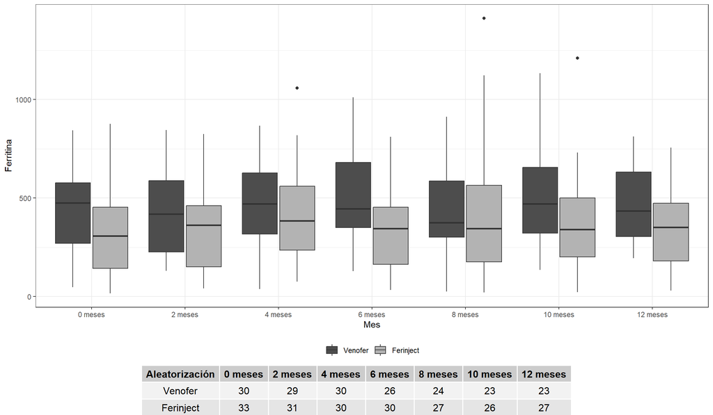

En la siguiente tabla se muestra, para cada mes de control y grupo de aleatorización:  
- Número de pacientes incluidos en el mes de control.  
- Número de pacientes con muestra de ferritina recogida.  
- Valor medio, desviación típica, mediana, Q1 y Q3 de la ferritina.

Nota:  
- Para comparar las diferencias de ferritina entre las ramas de aleatorización en un mismo momento temporal: ordenar la tabla por la columna Mes.  
- Para visualizar la evolución temporal de la ferritina dentro de cada rama: ordenar la tabla por la columna Aleatorización.

Distribución de la ferritina por mes

| Mes | Aleatorización | n | Pacientes con ferritina basal | media | sd | mediana | Q1 | Q3 |
| --- | --- | --- | --- | --- | --- | --- | --- | --- |
| 0 meses | Venofer | 30 | 30 | 428.6 | 208 | 475 | 269.5 | 576.8 |
| 0 meses | Ferinject | 34 | 33 | 337.7 | 211.8 | 308 | 144 | 453 |
| 2 meses | Venofer | 30 | 29 | 432.3 | 203.6 | 419 | 226 | 589 |
| 2 meses | Ferinject | 34 | 31 | 342.3 | 194 | 363 | 151 | 462 |
| 4 meses | Venofer | 30 | 30 | 457.1 | 205.3 | 471 | 317.8 | 627 |
| 4 meses | Ferinject | 31 | 30 | 410 | 232.6 | 385 | 235 | 560.8 |
| 6 meses | Venofer | 27 | 26 | 492.3 | 225.4 | 445.5 | 349.5 | 680 |
| 6 meses | Ferinject | 30 | 30 | 333.1 | 200.6 | 345 | 164 | 452.8 |
| 8 meses | Venofer | 26 | 24 | 444.5 | 231 | 375 | 302 | 586.5 |
| 8 meses | Ferinject | 29 | 27 | 396.8 | 329.7 | 346 | 176 | 565 |

[output cut: 4 more lines]

Distribución de la ferritina basal según el tiempo hasta el estudio

| Tiempo hasta inicio estudio | Aleatorización | n | Pacientes con ferritina basal | media | sd | mediana | Q1 | Q3 |
| --- | --- | --- | --- | --- | --- | --- | --- | --- |
| < 1 año | Venofer | 4 | 4 | 247.2 | 243.3 | 174.5 | 86.2 | 335.5 |
| < 1 año | Ferinject | 7 | 7 | 261.4 | 186.4 | 263 | 127.5 | 369 |
| 1-2 años | Venofer | 7 | 7 | 375.9 | 191.9 | 439 | 203 | 523 |
| 1-2 años | Ferinject | 7 | 7 | 383.6 | 220.3 | 414 | 252.5 | 483.5 |
| 2-3 años | Venofer | 4 | 4 | 331.2 | 210.2 | 381.5 | 237.5 | 475.2 |
| 2-3 años | Ferinject | 5 | 5 | 271.8 | 123.9 | 238 | 207 | 330 |
| 3-4 años | Venofer | 1 | 1 | 495 | NA | 495 | 495 | 495 |
| 3-4 años | Ferinject | 5 | 5 | 249.6 | 174.3 | 264 | 111 | 279 |
| >= 4 años | Venofer | 14 | 14 | 529.8 | 172.5 | 520.5 | 396 | 632.2 |
| >= 4 años | Ferinject | 10 | 9 | 447 | 257.2 | 324 | 271 | 690 |

### Niveles basales de la ferritina en cada rama

**Implicación clínica**

**Requisito.**

Para contrastar si una rama de la aleatorización ofrece mejores resultados que la otra rama, debemos confirmar que ambas ramas parten del mismo punto. ¿El nivel de ferritina basal es igual para cada rama de la aleatorización? En caso de no serlo, las diferencias entre grupos en los controles puede deberse a que no partían ambos del mismo punto.

**Implicación clínica**

```
##
##  Welch Two Sample t-test
##
## data:  Ferritina by Aleatorización
## t = 1.7163, df = 60.622, p-value = 0.09122
## alternative hypothesis: true difference in means between group Venofer and group Ferinject is not equal to 0
## 95 percent confidence interval:
##  -15.01051 196.68930
## sample estimates:
##   mean in group Venofer mean in group Ferinject
##                428.5667                337.7273
```

Gráficamente:

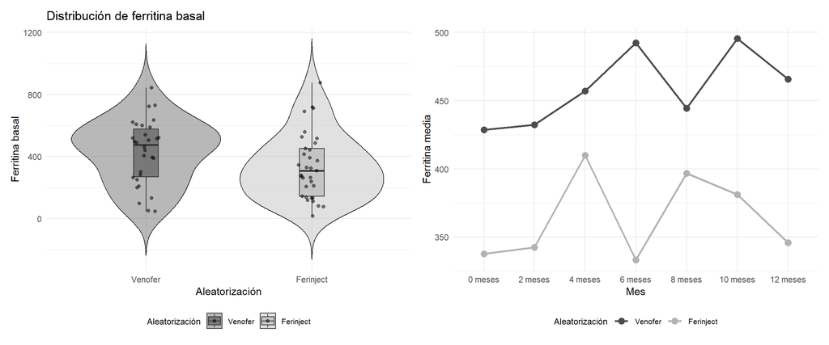

**Alternativa.**

En vez de trabajar con los valores de la ferritina, trabajamos con **el log de la ferritina (log-ferritina)**.

| Mes | Aleatorización | n | Pacientes con ferritina | media | sd | mediana | Q1 | Q3 | IQR |
| --- | --- | --- | --- | --- | --- | --- | --- | --- | --- |
| 0 meses | Venofer | 30 | 30 | 5.9 | 0.7 | 6.2 | 5.6 | 6.4 | 0.8 |
| 0 meses | Ferinject | 34 | 33 | 5.6 | 0.8 | 5.7 | 5 | 6.1 | 1.1 |
| 2 meses | Venofer | 30 | 29 | 5.9 | 0.6 | 6 | 5.4 | 6.4 | 1 |
| 2 meses | Ferinject | 34 | 31 | 5.6 | 0.8 | 5.9 | 5 | 6.1 | 1.1 |
| 4 meses | Venofer | 30 | 30 | 6 | 0.7 | 6.2 | 5.8 | 6.4 | 0.6 |
| 4 meses | Ferinject | 31 | 30 | 5.8 | 0.7 | 6 | 5.5 | 6.3 | 0.8 |
| 6 meses | Venofer | 27 | 26 | 6.1 | 0.5 | 6.1 | 5.9 | 6.5 | 0.6 |
| 6 meses | Ferinject | 30 | 30 | 5.5 | 0.9 | 5.8 | 5.1 | 6.1 | 1 |
| 8 meses | Venofer | 26 | 24 | 5.9 | 0.8 | 5.9 | 5.7 | 6.4 | 0.7 |
| 8 meses | Ferinject | 29 | 27 | 5.6 | 1 | 5.8 | 5.2 | 6.3 | 1.1 |

[output cut: 4 more lines]

**Implicación clínica**

El siguiente test muestra que **no hay evidencia suficiente para confirmar que el nivel de la log-ferritina basal en ambos grupos es diferente (p = 0.134)**. La diferencia estimada de medias es 0.30 (Venofer algo mayor). Esta diferencias no es estadísticamente significativa. Como está en log, la diferencia aproximada en la escala original es $e^{0.2978}$ = 1.35, es decir, la ferritina es un 35 % mayor en el grupo Venofer que en el grupo Ferinject y la diferencia no es estadísticamente significativa.

```
##
##  Welch Two Sample t-test
##
## data:  log_Ferritina by Aleatorización
## t = 1.5184, df = 60.994, p-value = 0.1341
## alternative hypothesis: true difference in means between group Venofer and group Ferinject is not equal to 0
## 95 percent confidence interval:
##  -0.09436563  0.68986892
## sample estimates:
##   mean in group Venofer mean in group Ferinject
##                5.871584                5.573833
```

Gráficamente:

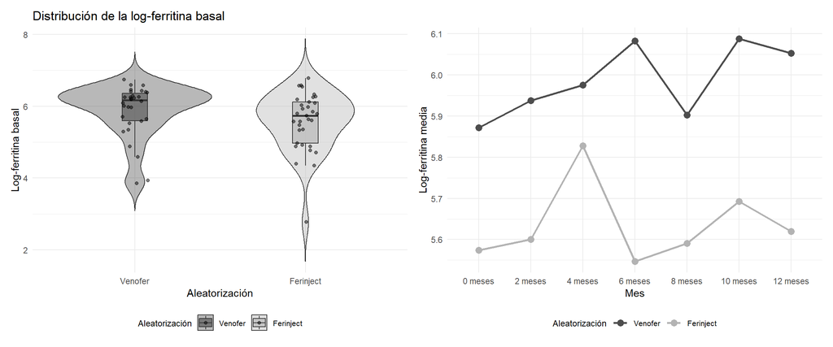

## Distribución de la log-ferritina

**Implicación clínica**

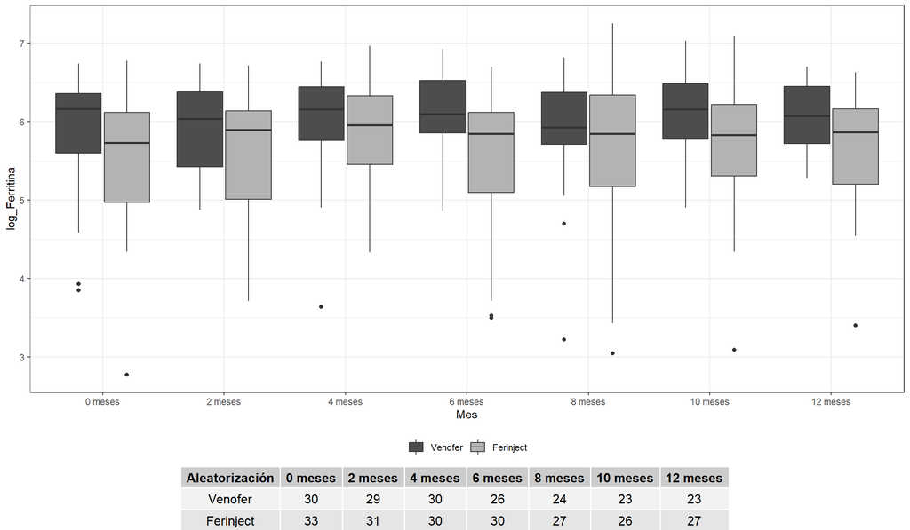

Distribución de la log-ferritina por Control

| Mes | Aleatorización | n | Pacientes con ferritina | media | sd | mediana | Q1 | Q3 |
| --- | --- | --- | --- | --- | --- | --- | --- | --- |
| 0 meses | Venofer | 30 | 30 | 5.9 | 0.7 | 6.2 | 5.6 | 6.4 |
| 0 meses | Ferinject | 34 | 33 | 5.6 | 0.8 | 5.7 | 5 | 6.1 |
| 2 meses | Venofer | 30 | 29 | 5.9 | 0.6 | 6 | 5.4 | 6.4 |
| 2 meses | Ferinject | 34 | 31 | 5.6 | 0.8 | 5.9 | 5 | 6.1 |
| 4 meses | Venofer | 30 | 30 | 6 | 0.7 | 6.2 | 5.8 | 6.4 |
| 4 meses | Ferinject | 31 | 30 | 5.8 | 0.7 | 6 | 5.5 | 6.3 |
| 6 meses | Venofer | 27 | 26 | 6.1 | 0.5 | 6.1 | 5.9 | 6.5 |
| 6 meses | Ferinject | 30 | 30 | 5.5 | 0.9 | 5.8 | 5.1 | 6.1 |
| 8 meses | Venofer | 26 | 24 | 5.9 | 0.8 | 5.9 | 5.7 | 6.4 |
| 8 meses | Ferinject | 29 | 27 | 5.6 | 1 | 5.8 | 5.2 | 6.3 |

[output cut: 4 more lines]

Distribución de la log-ferritina según el tiempo hasta el estudio

| Tiempo hasta inicio estudio | Aleatorización | n | Pacientes con ferritina | media | sd | mediana | Q1 | Q3 |
| --- | --- | --- | --- | --- | --- | --- | --- | --- |
| < 1 año | Venofer | 28 | 20 | 5.5 | 0.6 | 5.4 | 5.1 | 5.8 |
| < 1 año | Ferinject | 49 | 46 | 5.8 | 0.8 | 5.9 | 5.1 | 6.4 |
| 1-2 años | Venofer | 49 | 47 | 5.9 | 0.5 | 5.9 | 5.5 | 6.3 |
| 1-2 años | Ferinject | 49 | 43 | 5.4 | 1 | 5.6 | 4.9 | 6 |
| 2-3 años | Venofer | 28 | 22 | 5.7 | 0.9 | 6 | 5.7 | 6.3 |
| 2-3 años | Ferinject | 35 | 26 | 5.9 | 0.4 | 5.8 | 5.6 | 6.1 |
| 3-4 años | Venofer | 7 | 7 | 6.4 | 0.3 | 6.5 | 6.2 | 6.6 |
| 3-4 años | Ferinject | 35 | 27 | 5 | 0.8 | 5 | 4.4 | 5.8 |
| >= 4 años | Venofer | 98 | 89 | 6.2 | 0.4 | 6.3 | 6 | 6.5 |
| >= 4 años | Ferinject | 70 | 62 | 5.9 | 0.6 | 6.1 | 5.7 | 6.2 |

## Distribución del cambio de la log-ferritina respecto el valor basal

Distribución de la diferencia por mes de la log-ferritina respecto al nivel basal para cada una de las dos ramas (Venofer y Ferinject).

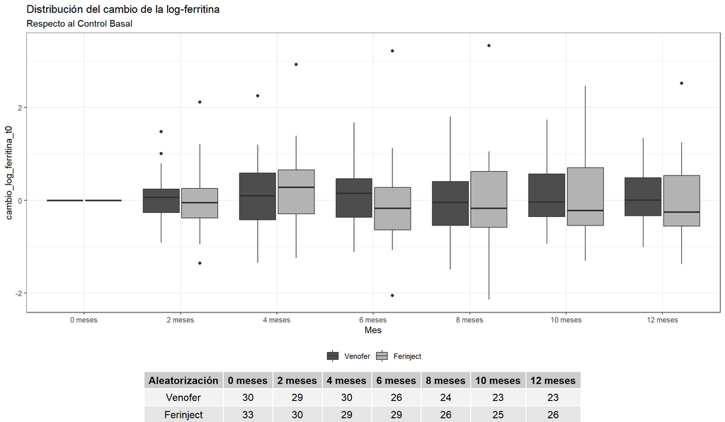

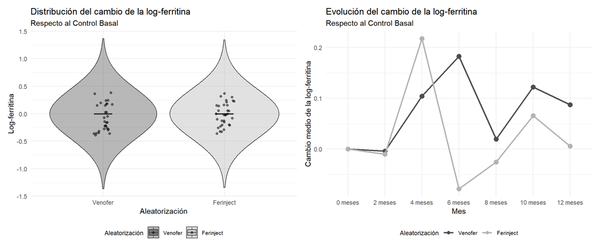

## Distribución del cambio de la log-ferritina respecto el control anterior

Distribución de la diferencia por mes de la log-ferritina respecto al control anterior para cada una de las dos ramas (Venofer y Ferinject).

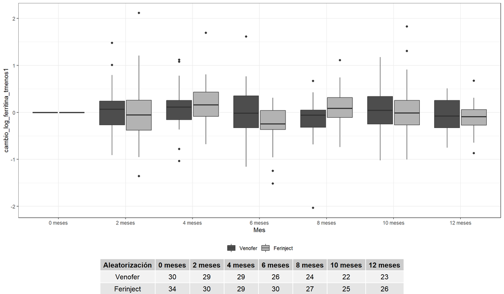

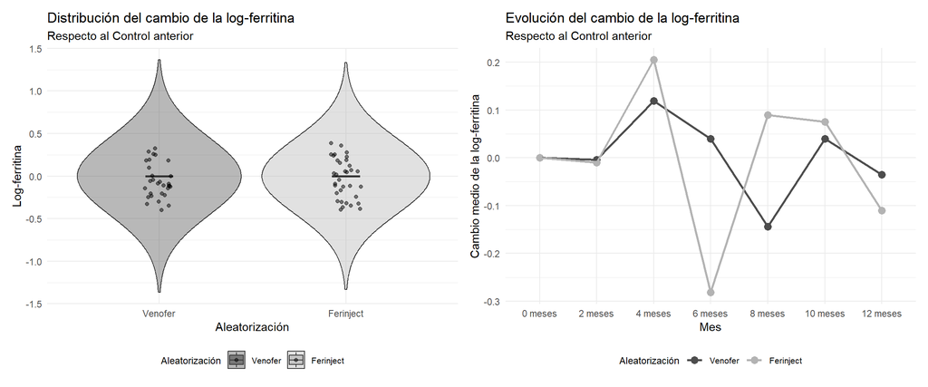

## Niveles óptimos

**Implicación clínica**

Los niveles óptimos de ferritina se sitúan entre 200 y 600 ng/mL o, análogamente, los valores óptimos de la log-ferritina se sitúan aproximadamente entre 5.29 y 6.39 (sin unidades de medida).

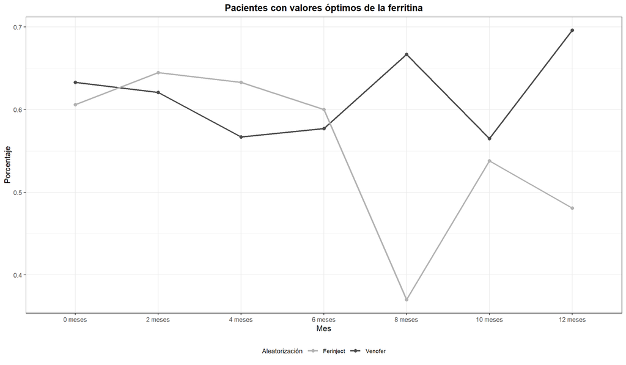

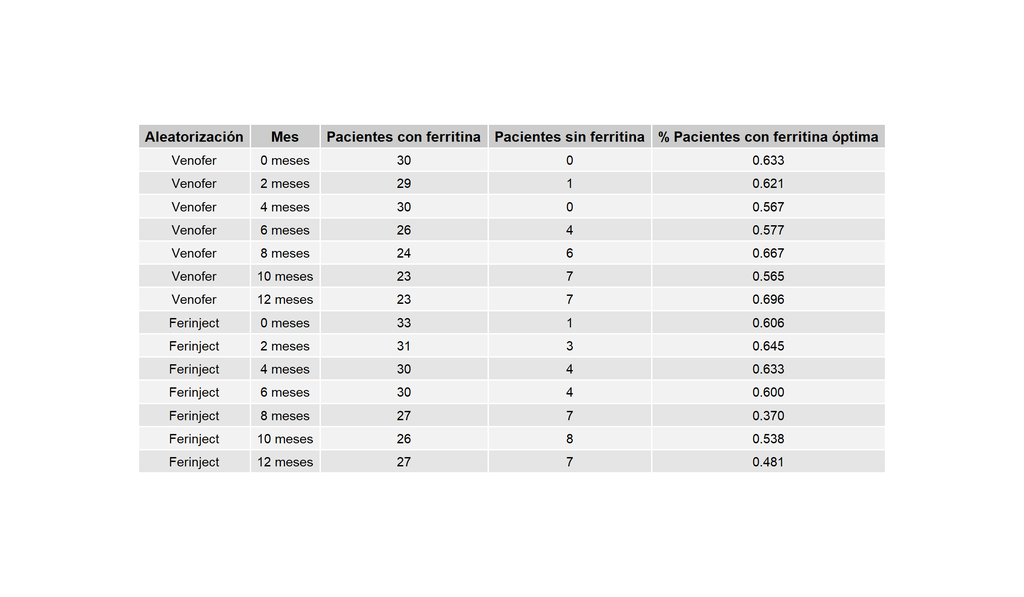

**Tabla para buscar qué pacientes están en rango óptimo o no óptimo por mes.**

| Paciente | Aleatorización | 0 meses | 2 meses | 4 meses | 6 meses | 8 meses | 10 meses | 12 meses |
| --- | --- | --- | --- | --- | --- | --- | --- | --- |
| 1 | Ferinject | 1 | 1 | 1 | 1 | 0 | 1 | 0 |
| 2 | Venofer | 1 | 1 | 1 | 1 | 1 | 1 | 0 |
| 3 | Ferinject | NA | 1 | 1 | 1 | 1 | 1 | 1 |
| 4 | Ferinject | 1 | 1 | 1 | 1 | 1 | 1 | 1 |
| 5 | Ferinject | 1 | NA | 1 | 1 | 0 | 0 | 1 |
| 6 | Ferinject | 1 | 0 | NA | NA | NA | NA | NA |
| 7 | Ferinject | 0 | 1 | 1 | 1 | 1 | 1 | 0 |
| 8 | Ferinject | 0 | 0 | 0 | 0 | 0 | 0 | 0 |
| 9 | Ferinject | 0 | NA | NA | NA | NA | NA | NA |
| 10 | Venofer | 0 | 1 | 1 | 0 | 0 | 0 | 1 |

[output cut: 54 more lines]

1: valor óptimo. 0: valor no óptimo. NA: sin ferritina

## Tipo de pauta

Se recategorizan las dosis de hierro previa a la aleatorización (Dosis Fe semanal) en Pautas (código)

```
Pauta basal (código)
    3     4 > 200
   38    23     3
```

**Implicación clínica**

@Jose Luis, valida que la Pauta anterior a la aleatorización de estos pacientes es correcta (tienen valores superiores a 200)

| id | Mes | Aleatorización | Dosis Fe semanal | Ferritina | Hb |
| --- | --- | --- | --- | --- | --- |
| 49 | 0 meses | Venofer | 250 | 208 | 13.8 |
| 53 | 0 meses | Ferinject | 1000 | 16 | 10.9 |
| 58 | 0 meses | Ferinject | 500 | 137 | 10.4 |

Ferritina media según la pauta antes del tratamiento

| Mes | Aleatorización | Pauta basal (código) | n | Pacientes con Ferritina | Ferritina media |
| --- | --- | --- | --- | --- | --- |
| 0 meses | Venofer | 3 | 18 | 18 | 444.9 |
| 0 meses | Venofer | 4 | 11 | 11 | 421.9 |
| 0 meses | Venofer | > 200 | 1 | 1 | 208.0 |
| 0 meses | Ferinject | 3 | 20 | 19 | 304.7 |
| 0 meses | Ferinject | 4 | 12 | 12 | 433.5 |
| 0 meses | Ferinject | > 200 | 2 | 2 | 76.5 |

**Implicación clínica**

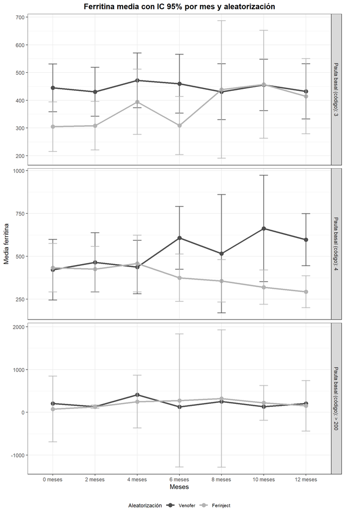

Tiempo medio hasta el inicio del estudio según la pauta de hierro previa

| Pauta basal (código) | Aleatorización | Pacientes | Tiempo medio hasta el inicio del estudio (meses) |
| --- | --- | --- | --- |
| 3 | Venofer | 126 | 63.4 |
| 3 | Ferinject | 140 | 49.4 |
| 4 | Venofer | 77 | 42.8 |
| 4 | Ferinject | 84 | 32.0 |
| > 200 | Venofer | 7 | 19.0 |
| > 200 | Ferinject | 14 | 2.5 |

**Implicación clínica**

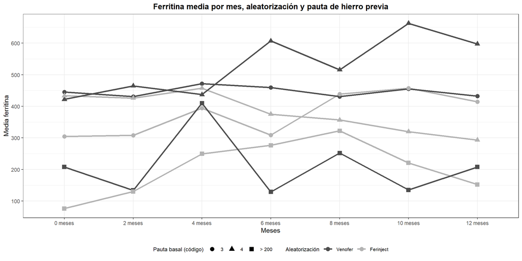